# (Just enough) Julia for scientific informatics, modeling, and reasoning

An operational learning approach to the essential computational competencies you need for your research, from ideas to publication and beyond

Author

Jeet Sukumaran

## 1 Overview

This tutorial introduces you to the digital side of paleontology. Instead of manually shading paper charts, you will use Julia to “hunt” for fossils across the globe. We will focus on the **Canidae** (the dog family) during the **Miocene** (about 23 to 5 million years ago), a critical time for their diversification.

**Proficiencies**

By the end of this activity, you will be able to:

1. **Download** real fossil data directly from the Paleobiology Database.
2. **Clean** that data so it is ready for a map.
3. **Visualize** exactly where these ancient dogs lived using a geographic map.

## 2 Preparation: Loading Your Tools

```julia
using PaleobiologyDB
using DataFrames
using GeoMakie, CairoMakie
```

## 3 Step 1: Download the Data

We will ask the database for every recorded occurrence of a Canidae fossil from the Miocene epoch. We specifically request **coordinates** so we know where each specimen was found.

```julia
canids = pbdb_occurrences(
    base_name = "Canidae",
    interval  = "Miocene",
    show      = ["coords", "classext"],
    vocab     = "pbdb"
)

println("Found ", nrow(canids), " Miocene canid fossils!")
```

```
Found 1345 Miocene canid fossils!
```

**Note**

The `vocab = "pbdb"` argument returns human-readable column names such as `"latitude"` and `"longitude"` rather than the raw API codes.

## 4 Step 2: Clean the Data

Real-world data is often messy. Some fossil records may be missing exact GPS coordinates. Before we can make a map, we must remove any rows that lack a latitude or longitude value.

```julia
clean_canids = dropmissing(canids, [:lat, :lng])

# The PBDB API may return coordinates as String — coerce to Float64 before plotting
clean_canids = transform(clean_canids,
    :lat => (x -> parse.(Float64, string.(x))) => :lat,
    :lng => (x -> parse.(Float64, string.(x))) => :lng,
)

println("Records with valid coordinates: ", nrow(clean_canids))
println("Records dropped: ", nrow(canids) - nrow(clean_canids))
```

```
Records with valid coordinates: 1345
Records dropped: 0
```

## 5 Step 3: Visualize on a World Map

Now we will plot these points on a world map. In the Miocene the continents were roughly where they are today, but the climate and faunal dispersal corridors were quite different.

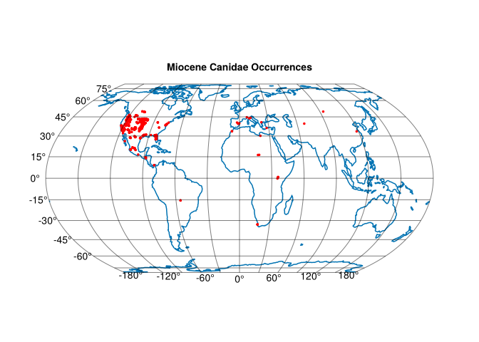

```
CairoMakie.Screen{IMAGE}
```

```julia
fig = Figure()
ax  = GeoAxis(fig[1, 1]; title = "Miocene Canidae Occurrences")

lines!(ax, GeoMakie.coastlines())  # land reference — without this the plot is blank
scatter!(ax, clean_canids.lng, clean_canids.lat;
         color = :red, markersize = 5)

display(fig)
```

## 6 Biological Context & Analysis

**Exercise 1**

Examine your map and address the following questions:

1. **Geographic Distribution** — Are the fossils concentrated on one continent (such as North America) or spread across multiple landmasses? Many canid lineages were actively diversifying and dispersing during the Miocene.
2. **Environmental Context** — Many Miocene canids were adapting to the expansion of open grasslands. Do the fossil localities correspond to regions that are currently deserts, forests, or plains?
3. **Data Quality** — Are there conspicuous gaps on your map? Absence of points does not necessarily mean canids were absent; it may reflect gaps in collection or digitization effort in those regions.

## 7 Optional: Compare with Another Taxon

Try swapping out the taxon and time interval to see a very different biogeographic pattern — the Cambrian Explosion of marine invertebrates.

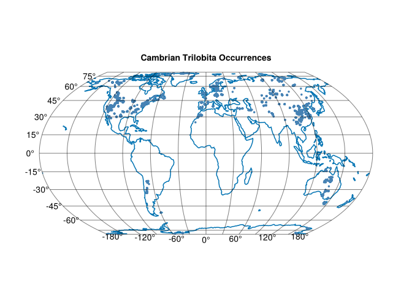

```
CairoMakie.Screen{IMAGE}
```

```julia
trilobites = pbdb_occurrences(
    base_name = "Trilobita",
    interval  = "Cambrian",
    show      = ["coords", "classext"],
    vocab     = "pbdb"
)

clean_trilobites = dropmissing(trilobites, [:lat, :lng])
clean_trilobites = transform(clean_trilobites,
    :lat => (x -> parse.(Float64, string.(x))) => :lat,
    :lng => (x -> parse.(Float64, string.(x))) => :lng,
)

fig2 = Figure()
ax2  = GeoAxis(fig2[1, 1]; title = "Cambrian Trilobita Occurrences")

lines!(ax2, GeoMakie.coastlines())
scatter!(ax2, clean_trilobites.lng, clean_trilobites.lat;
         color = :steelblue, markersize = 5)

display(fig2)
```

**Tip**

Compare the global spread of Cambrian trilobites with the distribution of Miocene canids. What does the difference in spatial pattern tell you about marine versus terrestrial dispersal during these two intervals?

Back to top